# ZeroStart_Fluid_Temperature

## Siemens: Funtional Data Analysis Pipeline

**Index**

1. Loading the datasets
2. Preprocessing steps
   - 2.1. Data wrangling on time series
   - 2.2. Data wrangling on additional features
   - 2.3. Merging time series datasets to add additional features
     - 2.3.1. Removal of testID only exists in one sensor
3. Window extraction
   - 3.1. Validating if there are partial or full missing values after the extraction
   - 3.2. Validating shape post-window extraction
   - 3.3. Scaling the post-window data: zero-alignment
   - 3.4. Merging scaled data with additional attributes of interest
   - 3.5. Balancing the specific attributes
   - 3.6. Windows visualization (balanced data)
4. FPCA characterization
   - 4.1. Functional PC1 plots (both systems): Characterization of FPC Scores
   - 4.2 Linear Regression for slope
5. Functional Regression
   - 5.1. Regression coefficients
   - 5.2. Coefficients visualization

```python
#!pip install scikit-fda
import os
os.chdir("../..")
```

```python
# Import libraries
import pandas as pd
import numpy as np
import matplotlib.pyplot as plt
import altair as alt
import random
import statsmodels.api as sm
from skfda.representation.grid import FDataGrid
from skfda.preprocessing.dim_reduction.projection import FPCA
from skfda.exploratory.visualization import FPCAPlot
from sklearn.preprocessing import OneHotEncoder
import skfda
from skfda.ml.regression import LinearRegression
from skfda.representation.basis import FDataBasis, FourierBasis
from skfda.exploratory.depth import IntegratedDepth, ModifiedBandDepth
from skfda.exploratory.visualization import Boxplot
# Import designed-functions
from window_extraction import calculate_window_values, calculate_window_data, Merge_data, align_to_zero, balance_index
from time_series_visualization import plot_all_time_series, plot_all_time_series_and_mean_fpca, plot_all_time_series_in_group
from functionalPCA import fpca_two_inputs, first_component_extraction, bootstrap, create_pc_scores_plots, visualize_regression
from functional_regression import Function_regression, coefficent_visualization
```

# 1. Loading the datasets

The path of the files can be change based on where the data is stored.

```python
# Import datasets
sensorA_System1 = pd.read_csv("RawData/System1_SensorA.csv")
sensorA_System2 = pd.read_csv("RawData/System2_SensorA.csv")
sensorB_System1 = pd.read_csv("RawData/System1_SensorB.csv")
sensorB_System2 = pd.read_csv("RawData/System2_SensorB.csv")
sensorA_System1_missing = pd.read_csv("RawData/SensorA_System1_missing values.csv")
sensorA_System2_missing = pd.read_csv("RawData/SensorA_System2_missing values.csv")
keyByTestID = pd.read_csv("RawData/Key by TestID.csv", parse_dates=['DateTime'])
```

# 2. Preprocesing Steps

## 2.1. Data wrangling on time series

```python
# Transpose dataset to make columns as timestamps and rows as tests

# Sensor A
A1_transposed = sensorA_System1.T.reset_index()
A1_transposed.columns = A1_transposed.iloc[0]
A1_transposed.rename(columns={A1_transposed.columns[0]: 'TestID'}, inplace=True)
A1_transposed = A1_transposed.drop(0)
A1_transposed['TestID'] = A1_transposed['TestID'].astype(int)

A2_transposed = sensorA_System2.T.reset_index()
A2_transposed.columns = A2_transposed.iloc[0]
A2_transposed.rename(columns={A2_transposed.columns[0]: 'TestID'}, inplace=True)
A2_transposed = A2_transposed.drop(0)
A2_transposed['TestID'] = A2_transposed['TestID'].astype(int)

A1_missing_transposed = sensorA_System1_missing.T.reset_index()
A1_missing_transposed.columns = A1_missing_transposed.iloc[0]
A1_missing_transposed.rename(columns={A1_missing_transposed.columns[0]: 'TestID'}, inplace=True)
A1_missing_transposed = A1_missing_transposed.drop(0)
A1_missing_transposed['TestID'] = A1_missing_transposed['TestID'].astype(int)

A2_missing_transposed = sensorA_System2_missing.T.reset_index()
A2_missing_transposed.columns = A2_missing_transposed.iloc[0]
A2_missing_transposed.rename(columns={A2_missing_transposed.columns[0]: 'TestID'}, inplace=True)
A2_missing_transposed = A2_missing_transposed.drop(0)
A2_missing_transposed['TestID'] = A2_missing_transposed['TestID'].astype(int)

# Sensor B
B1_transposed = sensorB_System1.T.reset_index()
B1_transposed.columns = B1_transposed.iloc[0]
B1_transposed.rename(columns={B1_transposed.columns[0]: 'TestID'}, inplace=True)
B1_transposed = B1_transposed.drop(0)
B1_transposed['TestID'] = B1_transposed['TestID'].astype(int)

B2_transposed = sensorB_System2.T.reset_index()
B2_transposed.columns = B2_transposed.iloc[0]
B2_transposed.rename(columns={B2_transposed.columns[0]: 'TestID'}, inplace=True)
B2_transposed = B2_transposed.drop(0)
B2_transposed['TestID'] = B2_transposed['TestID'].astype(int)
```

```python
# Complete A1 and A2 with the missing values
A1_transposed_mid = A1_transposed[~A1_transposed.TestID.isin(A1_missing_transposed.TestID)]
A1_transposed = pd.concat([A1_transposed_mid, A1_missing_transposed], axis=0)
A2_transposed_mid = A2_transposed[~A2_transposed.TestID.isin(A2_missing_transposed.TestID)]
A2_transposed = pd.concat([A2_transposed_mid, A2_missing_transposed], axis=0)
```

## 2.2. Data wrangling on additional features

```python
# Relabeling System Values
keyByTestID["System"] = keyByTestID["System"].replace({"System 2A":"System 2","System 2B":"System 2"})

# Create new column to fill fluid temperature NA's
# Note: Fluid temperature: If specified, take as the temperature of the sample fluid. The rest of the system temperature can be taken as ambient temperature.
keyByTestID['Fluid_Temperature_Filled'] = keyByTestID['Fluid Temperature'].combine_first(keyByTestID['AmbientTemperature'])

# Binning

# Categorize 'FluidType' into Blood and Aqueous
keyByTestID['FluidTypeBin'] = np.where(keyByTestID['FluidType'].str.startswith('Eurotrol'), 'Aqueous', 'Blood')

# Categorize 'AgeOfCardInDaysAtTimeOfTest' into bins
keyByTestID["CardAgeBin"] = pd.cut(keyByTestID["AgeOfCardInDaysAtTimeOfTest"], bins=[0, 9, 28, 56, 84, 112, 140, 168, 196, 224, 252],
                                   labels=['[0-9]', '(9-28]', '(28-56]', '(56-84]', '(84-112]', '(112-140]', '(140-168]', '(168-196]', '(196-224]', '(224-252]'])


# Categorize 'Fluid_Temperature_Filled' into bins
keyByTestID["FluidTempBin"] = pd.cut(keyByTestID["Fluid_Temperature_Filled"], bins=[-1, 20, 25, 100], labels=['Below 20', '20-25', 'Above 25'])

# Filtering successful tests
keyByTestID = keyByTestID[keyByTestID['ReturnCode'].isin(['Success','UnderReportableRange'])]
```

## 2.3. Merging time series datasets to add additional features

```python
# Merge dataset with keyByTestID and delete unmatched tests
keyByTestID['TestID'] = keyByTestID['TestID'].astype(int)
keyByTestID['System'] = keyByTestID['System'].astype(str)

A1_keyByTestID = keyByTestID[(keyByTestID['Sensor'] == 'Sensor A') & (keyByTestID['System'] == 'System 1')]
A1_Merged = pd.merge(A1_keyByTestID,A1_transposed,how='inner', on=['TestID'])
A1_transposed = A1_transposed[A1_transposed['TestID'].isin(A1_Merged['TestID'])]

A2_keyByTestID = keyByTestID.loc[(keyByTestID['Sensor'] == 'Sensor A') & (keyByTestID['System'] != 'System 1')]
A2_Merged = pd.merge(A2_keyByTestID,A2_transposed,how='inner', on=['TestID'])
A2_transposed = A2_transposed[A2_transposed['TestID'].isin(A2_Merged['TestID'])]

sensorA_System1 = sensorA_System1.loc[:, sensorA_System1.columns.isin(A1_Merged['TestID'].astype(str))]
sensorA_System2 = sensorA_System2.loc[:, sensorA_System2.columns.isin(A2_Merged['TestID'].astype(str))]


B1_keyByTestID = keyByTestID[(keyByTestID['Sensor'] == 'Sensor B') & (keyByTestID['System'] == 'System 1')]
B1_Merged = pd.merge(B1_keyByTestID,B1_transposed,how='inner', on=['TestID'])
B1_transposed = B1_transposed[B1_transposed['TestID'].isin(B1_Merged['TestID'])]

B2_keyByTestID = keyByTestID.loc[(keyByTestID['Sensor'] == 'Sensor B') & (keyByTestID['System'] != 'System 1')]
B2_Merged = pd.merge(B2_keyByTestID,B2_transposed,how='inner', on=['TestID'])
B1_transposed = B2_transposed[B2_transposed['TestID'].isin(A2_Merged['TestID'])]

sensorB_System1 = sensorB_System1.loc[:, sensorB_System1.columns.isin(B1_Merged['TestID'].astype(str))]
sensorB_System2 = sensorB_System2.loc[:, sensorB_System2.columns.isin(B2_Merged['TestID'].astype(str))]

print('A1: ', A1_Merged.shape)
print('A2: ', A2_Merged.shape)
print('B1: ', B1_Merged.shape)
print('B2: ', B2_Merged.shape)
```

```
A1:  (3382, 3380)
A2:  (7743, 3371)
B1:  (3375, 3380)
B2:  (7745, 3371)
```

### 2.3.1. Removal of testID only exists in one sensor

```python
# Note: Only run once. If not, restart the kernel and run from the beggining again.
A1_Merged = A1_Merged[A1_Merged["TestID"].isin(B1_Merged["TestID"])]
B1_Merged = B1_Merged[B1_Merged["TestID"].isin(A1_Merged["TestID"])]

A2_Merged = A2_Merged[A2_Merged["TestID"].isin(B2_Merged["TestID"])]
B2_Merged = B2_Merged[B2_Merged["TestID"].isin(A2_Merged["TestID"])]
print('A1: ', A1_Merged.shape)
print('A2: ', A2_Merged.shape)
print('B1: ', B1_Merged.shape)
print('B2: ', B2_Merged.shape)
```

```
A1:  (3374, 3380)
A2:  (7743, 3371)
B1:  (3374, 3380)
B2:  (7743, 3371)
```

# 3. Window extraction

```python
# Match window values of Sensor A for each test
calDelimit = 11
cal_window_size = 8
sampleDelimit = 15
sample_window_size = 5

# Sensor A
cal_window_start, cal_window_end, sample_window_start, sample_window_end = calculate_window_values(bubble_start=A1_Merged['BubbleDetectTime'],
                                                                                                   sample_start=A1_Merged['SampleDetectTime'],
                                                                                                   calDelimit_input=calDelimit,
                                                                                                   cal_window_size_input=cal_window_size,
                                                                                                   sampleDelimit_input=sampleDelimit,
                                                                                                   sample_window_size_input=sample_window_size)
A1_Merged['cal_window_start']=cal_window_start
A1_Merged['cal_window_end']=cal_window_end
A1_Merged['sample_window_start']=sample_window_start
A1_Merged['sample_window_end']=sample_window_end


cal_window_start, cal_window_end, sample_window_start, sample_window_end = calculate_window_values(bubble_start=A2_Merged['BubbleDetectTime'],
                                                                                                   sample_start=A2_Merged['SampleDetectTime'],
                                                                                                   calDelimit_input=calDelimit,
                                                                                                   cal_window_size_input=cal_window_size,
                                                                                                   sampleDelimit_input=sampleDelimit,
                                                                                                   sample_window_size_input=sample_window_size)
A2_Merged['cal_window_start']=cal_window_start
A2_Merged['cal_window_end']=cal_window_end
A2_Merged['sample_window_start']=sample_window_start
A2_Merged['sample_window_end']=sample_window_end


# sensor B

# Match window values of Sensor B for each test
calDelimit = 20
cal_window_size = 18
sampleDelimit_blood = 24
sampleDelimit_aqueous = 30
sample_window_size = 4

B1_Merged['cal_window_start'], B1_Merged['cal_window_end'], \
B1_Merged['sample_window_start'], B1_Merged['sample_window_end'] = zip(*B1_Merged.apply(
    lambda row: calculate_window_values(
        bubble_start=row['BubbleDetectTime'],
        sample_start=row['SampleDetectTime'],
        calDelimit_input=calDelimit,
        cal_window_size_input=cal_window_size,
        sampleDelimit_input=sampleDelimit_aqueous if row['FluidType'].startswith('Eurotrol') else sampleDelimit_blood,
        sample_window_size_input=sample_window_size
    ),
    axis=1
))

# For sensor B in system 2, blood and aqueous
B2_Merged['cal_window_start'], B2_Merged['cal_window_end'], \
B2_Merged['sample_window_start'], B2_Merged['sample_window_end'] = zip(*B2_Merged.apply(
    lambda row: calculate_window_values(
        bubble_start=row['BubbleDetectTime'],
        sample_start=row['SampleDetectTime'],
        calDelimit_input=calDelimit,
        cal_window_size_input=cal_window_size,
        sampleDelimit_input=sampleDelimit_aqueous if row['FluidType'].startswith('Eurotrol') else sampleDelimit_blood,
        sample_window_size_input=sample_window_size
    ),
    axis=1
))
```

```python
# Adds TestIDs as index to the values post-window extraction
# System 1 - Sensor A

A1_cal_window = []
A1_sample_window = []
for i in range(len(A1_Merged)):
    cal_window, sample_window = calculate_window_data(A1_Merged.iloc[i, :])
    A1_cal_window.append(cal_window.values)
    A1_sample_window.append(sample_window.values)
A1_cal_window = pd.DataFrame(A1_cal_window)
A1_sample_window = pd.DataFrame(A1_sample_window)
A1_cal_window['TestID'] = A1_sample_window['TestID'] = A1_Merged['TestID'].astype(int)
A1_sample_window.set_index('TestID',inplace=True)
A1_cal_window.set_index('TestID',inplace=True)

# System 2 - Sensor A

A2_cal_window = []
A2_sample_window = []
for i in range(len(A2_Merged)):
    cal_window, sample_window = calculate_window_data(A2_Merged.iloc[i, :])
    A2_cal_window.append(cal_window.values)
    A2_sample_window.append(sample_window.values)
A2_cal_window = pd.DataFrame(A2_cal_window)
A2_sample_window = pd.DataFrame(A2_sample_window)
A2_cal_window['TestID'] = A2_sample_window['TestID'] = A2_Merged['TestID'].astype(int)
A2_sample_window.set_index('TestID',inplace=True)
A2_cal_window.set_index('TestID',inplace=True)

# System 1 - Sensor B

B1_cal_window = []
B1_sample_window = []
for i in range(len(B1_Merged)):
    cal_window, sample_window = calculate_window_data(B1_Merged.iloc[i, :])
    B1_cal_window.append(cal_window.values)
    B1_sample_window.append(sample_window.values)
B1_cal_window = pd.DataFrame(B1_cal_window)
B1_sample_window = pd.DataFrame(B1_sample_window)
B1_cal_window['TestID'] = B1_sample_window['TestID'] = B1_Merged['TestID'].astype(int)
B1_sample_window.set_index('TestID',inplace=True)
B1_cal_window.set_index('TestID',inplace=True)

# System 2 - Sensor B

B2_cal_window = []
B2_sample_window = []
for i in range(len(B2_Merged)):
    cal_window, sample_window = calculate_window_data(B2_Merged.iloc[i, :])
    B2_cal_window.append(cal_window.values)
    B2_sample_window.append(sample_window.values)
B2_cal_window = pd.DataFrame(B2_cal_window)
B2_sample_window = pd.DataFrame(B2_sample_window)
B2_cal_window['TestID'] = B2_sample_window['TestID'] = B2_Merged['TestID'].astype(int)
B2_sample_window.set_index('TestID',inplace=True)
B2_cal_window.set_index('TestID',inplace=True)
```

## 3.1. Validating if there are partial or full missing values after the extraction

```python
A1_cal_window_drop_index = A1_cal_window.loc[A1_cal_window.isna().sum(axis=1)!=0].index
A2_cal_window_drop_index = A2_cal_window.loc[A2_cal_window.isna().sum(axis=1)!=0].index

A1_sample_window_drop_index = A1_sample_window.loc[A1_sample_window.isna().sum(axis=1)!=0].index
A2_sample_window_drop_index = A2_sample_window.loc[A2_sample_window.isna().sum(axis=1)!=0].index

B1_cal_window_drop_index = B1_cal_window.loc[B1_cal_window.isna().sum(axis=1)!=0].index
B2_cal_window_drop_index = B2_cal_window.loc[B2_cal_window.isna().sum(axis=1)!=0].index

B1_sample_window_drop_index = B1_sample_window.loc[B1_sample_window.isna().sum(axis=1)!=0].index
B2_sample_window_drop_index = B2_sample_window.loc[B2_sample_window.isna().sum(axis=1)!=0].index

# Check if missing values in different windows is different
print("The missing value in calibration window:",A1_cal_window_drop_index)
print("The missing value in sample window:",A1_sample_window_drop_index)
print("The missing value in calibration window:",A2_cal_window_drop_index)
print("The missing value in sample window:",A2_sample_window_drop_index)

print("The missing value in calibration window:",B1_cal_window_drop_index)
print("The missing value in sample window:",B1_sample_window_drop_index)
print("The missing value in calibration window:",B2_cal_window_drop_index)
print("The missing value in sample window:",B2_sample_window_drop_index)
```

```
The missing value in calibration window: Float64Index([], dtype='float64', name='TestID')
The missing value in sample window: Float64Index([], dtype='float64', name='TestID')
The missing value in calibration window: Int64Index([], dtype='int64', name='TestID')
The missing value in sample window: Int64Index([], dtype='int64', name='TestID')
The missing value in calibration window: Float64Index([], dtype='float64', name='TestID')
The missing value in sample window: Float64Index([], dtype='float64', name='TestID')
The missing value in calibration window: Float64Index([], dtype='float64', name='TestID')
The missing value in sample window: Float64Index([], dtype='float64', name='TestID')
```

## 3.2. Validating data shape post-window extraction

```python
# Set index for Merge datasets
A1_Merged.set_index("TestID", inplace=True)
A2_Merged.set_index("TestID", inplace=True)
B1_Merged.set_index("TestID", inplace=True)
B2_Merged.set_index("TestID", inplace=True)

# Find missing value
print("The problem indexes after extract the window are:",A1_Merged.index.difference(A1_cal_window.index))
print("The problem indexes after extract the window are:",A1_Merged.index.difference(A1_sample_window.index))
print("The problem indexes after extract the window are:",A2_Merged.index.difference(A2_cal_window.index))
print("The problem indexes after extract the window are:",A2_Merged.index.difference(A2_sample_window.index))

print("The problem indexes after extract the window are:",B1_Merged.index.difference(B1_cal_window.index))
print("The problem indexes after extract the window are:",B1_Merged.index.difference(B1_sample_window.index))
print("The problem indexes after extract the window are:",B2_Merged.index.difference(B2_cal_window.index))
print("The problem indexes after extract the window are:",B2_Merged.index.difference(B2_sample_window.index))

A1_Merged = A1_Merged.drop(A1_Merged.index.difference(A1_cal_window.index))
A1_Merged = A1_Merged.drop(A1_Merged.index.difference(A1_sample_window.index))
A2_Merged = A2_Merged.drop(A2_Merged.index.difference(A2_cal_window.index))
A2_Merged = A2_Merged.drop(A2_Merged.index.difference(A2_sample_window.index))

B1_Merged = B1_Merged.drop(B1_Merged.index.difference(B1_cal_window.index))
B1_Merged = B1_Merged.drop(B1_Merged.index.difference(B1_sample_window.index))
B2_Merged = B2_Merged.drop(B2_Merged.index.difference(B2_cal_window.index))
B2_Merged = B2_Merged.drop(B2_Merged.index.difference(B2_sample_window.index))

# Clear the Nan in index of sensor A
A1_cal_window = A1_cal_window[~A1_cal_window.index.isna()]
A1_sample_window = A1_sample_window[~A1_sample_window.index.isna()]
A2_cal_window = A2_cal_window[~A2_cal_window.index.isna()]
A2_sample_window = A2_sample_window[~A2_sample_window.index.isna()]

# Clear the Nan in index of sensor B
B1_cal_window = B1_cal_window[~B1_cal_window.index.isna()]
B1_sample_window = B1_sample_window[~B1_sample_window.index.isna()]
B2_cal_window = B2_cal_window[~B2_cal_window.index.isna()]
B2_sample_window = B2_sample_window[~B2_sample_window.index.isna()]
```

```
The problem indexes after extract the window are: Int64Index([12470355, 12470361, 12470365, 12537663, 12539049, 12622570], dtype='int64', name='TestID')
The problem indexes after extract the window are: Int64Index([12470355, 12470361, 12470365, 12537663, 12539049, 12622570], dtype='int64', name='TestID')
The problem indexes after extract the window are: Int64Index([], dtype='int64', name='TestID')
The problem indexes after extract the window are: Int64Index([], dtype='int64', name='TestID')
The problem indexes after extract the window are: Int64Index([12622570], dtype='int64', name='TestID')
The problem indexes after extract the window are: Int64Index([12622570], dtype='int64', name='TestID')
The problem indexes after extract the window are: Int64Index([3518677, 3518678], dtype='int64', name='TestID')
The problem indexes after extract the window are: Int64Index([3518677, 3518678], dtype='int64', name='TestID')
```

```python
# Shape of the subsets of time series after the extraction from the windows

# Cal Window
print('Shape of the time series after extraction')
print('A1_cal_window: ', A1_cal_window.shape)
print('A2_cal_window: ', A2_cal_window.shape)
print('B1_cal_window: ', B1_cal_window.shape)
print('B2_cal_window: ', B2_cal_window.shape)

# Sample Window
print('A1_sample_window: ', A1_sample_window.shape)
print('A2_sample_window: ', A2_sample_window.shape)
print('B1_sample_window: ', B1_sample_window.shape)
print('B2_sample_window: ', B2_sample_window.shape)

# We can delete the unmatch index but it is not necessary
```

```
Shape of the time series after extraction
A1_cal_window:  (3368, 41)
A2_cal_window:  (7743, 41)
B1_cal_window:  (3373, 91)
B2_cal_window:  (7741, 91)
A1_sample_window:  (3368, 26)
A2_sample_window:  (7743, 26)
B1_sample_window:  (3373, 21)
B2_sample_window:  (7741, 21)
```

## 3.3. Scaling the post-window data: zero-alignment

```python
# Cal Window

A1_cal_window_zero = align_to_zero(A1_cal_window)
A2_cal_window_zero = align_to_zero(A2_cal_window)
B1_cal_window_zero = align_to_zero(B1_cal_window)
B2_cal_window_zero = align_to_zero(B2_cal_window)


# Sample Window

A1_sample_window_zero = align_to_zero(A1_sample_window)
A2_sample_window_zero = align_to_zero(A2_sample_window)
B1_sample_window_zero = align_to_zero(B1_sample_window)
B2_sample_window_zero = align_to_zero(B2_sample_window)
```

## 3.4. Merging scaled data with additional attributes of interest

```python
# Combine data: Merge the zero-aligned time series with "FluidType", "AgeOfCardInDaysAtTimeOfTest", "Fluid_Temperature_Filled", "FluidTypeBin", "CardAgeBin", "FluidTempBin"
A1_cal_window_combine = Merge_data(A1_cal_window_zero,A1_Merged)
A2_cal_window_combine = Merge_data(A2_cal_window_zero,A2_Merged)

B1_cal_window_combine = Merge_data(B1_cal_window_zero,B1_Merged)
B2_cal_window_combine = Merge_data(B2_cal_window_zero,B2_Merged)

## Sample window
A1_sample_window_combine = Merge_data(A1_sample_window_zero,A1_Merged)
A2_sample_window_combine = Merge_data(A2_sample_window_zero,A2_Merged)

B1_sample_window_combine = Merge_data(B1_sample_window_zero,B1_Merged)
B2_sample_window_combine = Merge_data(B2_sample_window_zero,B2_Merged)
```

## 3.5. Balancing the specific attributes

```python
System1_Index, System2_Index =  balance_index(A1_cal_window_combine,A2_cal_window_combine,"FluidTempBin")
```

```
System1 Sensor A & B distribution:
 Below 20    72
20-25       72
Above 25    72
Name: FluidTempBin, dtype: int64

 System2 Sensor A & B distribution:
 Below 20    72
20-25       72
Above 25    72
Name: FluidTempBin, dtype: int64
```

```python
# Balanced data
A1_cal_window_combine_balanced = A1_cal_window_combine.loc[System1_Index]
A1_sample_window_combine_balanced = A1_sample_window_combine.loc[System1_Index]
A2_cal_window_combine_balanced = A2_cal_window_combine.loc[System2_Index]
A2_sample_window_combine_balanced = A2_sample_window_combine.loc[System2_Index]

B1_cal_window_combine_balanced = B1_cal_window_combine.loc[System1_Index]
B1_sample_window_combine_balanced = B1_sample_window_combine.loc[System1_Index]
B2_cal_window_combine_balanced = B2_cal_window_combine.loc[System2_Index]
B2_sample_window_combine_balanced = B2_sample_window_combine.loc[System2_Index]
```

## 3.6. Windows visualization

### Fluid Temperature

#### System 1 and System 2: Sensor A - Cal and Sample Windows

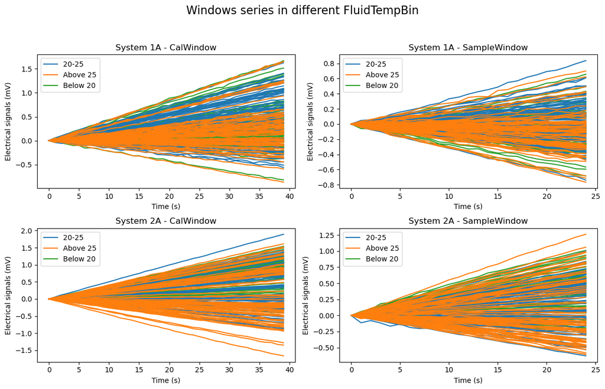

```python
# Plot all the balanced time series from the window extraction
plot_all_time_series_in_group(A1_cal_window_combine_balanced, A1_sample_window_combine_balanced, A2_cal_window_combine_balanced, A2_sample_window_combine_balanced, "FluidTempBin", "System 1A - CalWindow", "System 1A - SampleWindow","System 2A - CalWindow", "System 2A - SampleWindow")
```

#### System 1 and System 2: Sensor B - Cal and Sample Windows

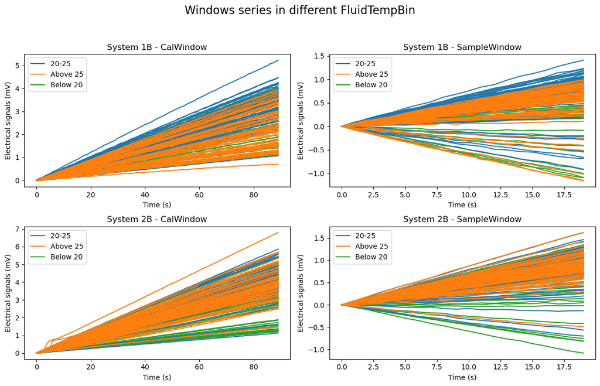

```python
# Plot all the balanced time series from the window extraction
plot_all_time_series_in_group(B1_cal_window_combine_balanced, B1_sample_window_combine_balanced, B2_cal_window_combine_balanced, B2_sample_window_combine_balanced, "FluidTempBin", "System 1B - CalWindow", "System 1B - SampleWindow","System 2B - CalWindow", "System 2B - SampleWindow")
```

# 4. FPCA characterization

## 4.1. Functional PC1 plots (both systems) and Characterization of FPC Scores

The following seccion will introduce

1. Percentage of variance explain by the components.
2. Time series with the major contribution on the components.
3. Plot 1-2: All the waveforms and the mean function.
4. Plot 3-4: First two components in different systems.
5. Plot 5: First component (eigenfunction) of the two systems.
6. Plot 6: The confidence interval of the mean first component computed using bootstrap.
7. Plot 7-8: The boxplots of the generated samples of the first component. The boxplots show the different percentile about the first component.
   - Red dashed lines indicate detected outliers.
   - Red area shows the box region.
8. Plot 9-12: Eigenvalues (scores) colored-mapping by attributes.

### System 1 versus System 2: Sensor A - Cal Window

```
S1 Explain variance PC1 (%):  99.87479090037866
S1 Explain variance PC2 (%):  0.036057394942360814
S2 Explain variance PC1 (%):  99.9614282456095
S2 Explain variance PC2 (%):  0.014689403106262619
The time series contributing most to PC1 is at index 38 with TestID 12191139.0
The time series contributing most to PC2 is at index 191 with TestID 12516002.0
The time series contributing most to PC1 is at index 188 with TestID 3568595
The time series contributing most to PC2 is at index 165 with TestID 3568995
```

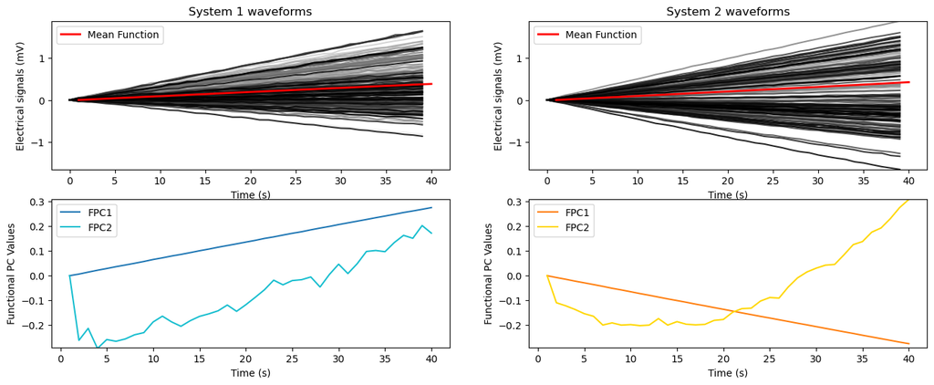

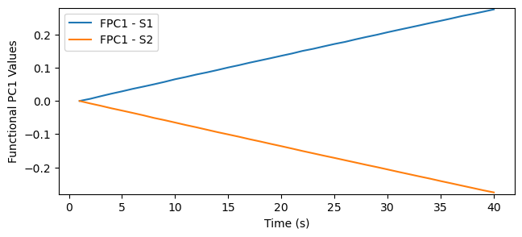

```
--------------------------------------------------- Bootstrap -------------------------------------------------------------------------------------------
Confidence Interval of 1st component
The number of sampling is 72
The boxplot of 1st Component
```

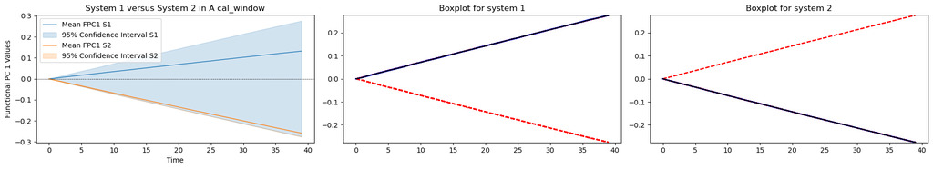

```
--------------------------------------------------- PCA Scores -------------------------------------------------------------------------------------------
```

[interactive chart not shown]

```python
pc_scores_s1_A_cal_window, pc_scores_s2_A_cal_window,fpca_s1_A_cal_window,fpca_s2_A_cal_window = fpca_two_inputs(A1_cal_window_combine_balanced.iloc[:,:-6], A2_cal_window_combine_balanced.iloc[:,:-6], color_fpc1_s1='tab:blue', color_fpc2_s1='tab:cyan', color_fpc1_s2='tab:orange', color_fpc2_s2='gold')
print("--------------------------------------------------- Bootstrap -------------------------------------------------------------------------------------------")
ac1, ac2 = bootstrap(A1_cal_window_combine_balanced, A2_cal_window_combine_balanced,"A","cal_window",features="FluidTempBin")
print("--------------------------------------------------- PCA Scores -------------------------------------------------------------------------------------------")
create_pc_scores_plots(pc_scores_s1_A_cal_window, pc_scores_s2_A_cal_window, A1_cal_window_combine_balanced, A2_cal_window_combine_balanced,features="FluidTempBin")
```

### System 1 versus System 2: Sensor A - Sample Window

```
S1 Explain variance PC1 (%):  99.53201594453768
S1 Explain variance PC2 (%):  0.16022779574395768
S2 Explain variance PC1 (%):  99.85342583558673
S2 Explain variance PC2 (%):  0.06882348112078512
The time series contributing most to PC1 is at index 89 with TestID 12395731.0
The time series contributing most to PC2 is at index 70 with TestID 12191109.0
The time series contributing most to PC1 is at index 187 with TestID 3569417
The time series contributing most to PC2 is at index 140 with TestID 3557978
```

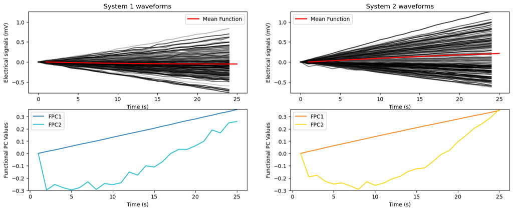

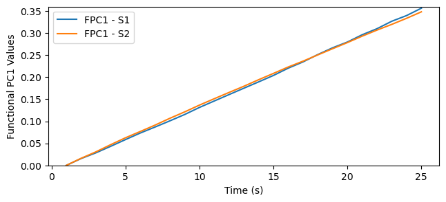

```
--------------------------------------------------- Bootstrap -------------------------------------------------------------------------------------------
Confidence Interval of 1st component
The number of sampling is 72
The boxplot of 1st Component
```

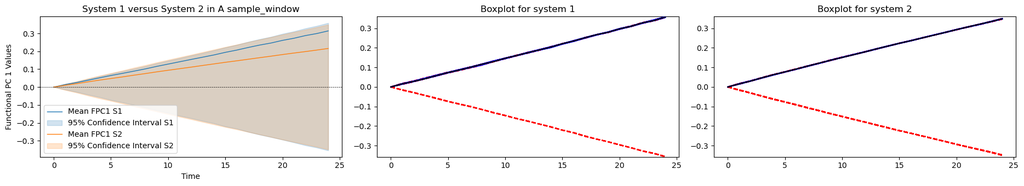

```
--------------------------------------------------- PCA Scores -------------------------------------------------------------------------------------------
```

[interactive chart not shown]

```python
pc_scores_s1_A_sample_window, pc_scores_s2_A_sample_window,fpca_s1_A_sample_window,fpca_s2_A_sample_window = fpca_two_inputs(A1_sample_window_combine_balanced.iloc[:,:-6], A2_sample_window_combine_balanced.iloc[:,:-6], color_fpc1_s1='tab:blue', color_fpc2_s1='tab:cyan', color_fpc1_s2='tab:orange', color_fpc2_s2='gold')
print("--------------------------------------------------- Bootstrap -------------------------------------------------------------------------------------------")
as1,as2 = bootstrap(A1_sample_window_combine_balanced, A2_sample_window_combine_balanced,"A","sample_window",features="FluidTempBin")
print("--------------------------------------------------- PCA Scores -------------------------------------------------------------------------------------------")
create_pc_scores_plots(pc_scores_s1_A_sample_window, pc_scores_s2_A_sample_window, A1_sample_window_combine_balanced, A2_sample_window_combine_balanced,features="FluidTempBin")
```

### System 1 versus System 2: Sensor B - Cal Window

```
S1 Explain variance PC1 (%):  99.9254205647006
S1 Explain variance PC2 (%):  0.040535697006909434
S2 Explain variance PC1 (%):  99.89060906906502
S2 Explain variance PC2 (%):  0.08438203098113882
The time series contributing most to PC1 is at index 89 with TestID 12395731.0
The time series contributing most to PC2 is at index 61 with TestID 12514378.0
The time series contributing most to PC1 is at index 165 with TestID 3568995.0
The time series contributing most to PC2 is at index 83 with TestID 3547583.0
```

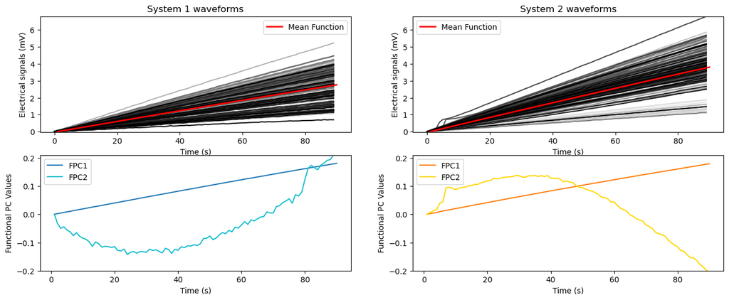

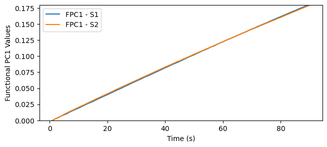

```
--------------------------------------------------- Bootstrap -------------------------------------------------------------------------------------------
Confidence Interval of 1st component
The number of sampling is 72
The boxplot of 1st Component
```

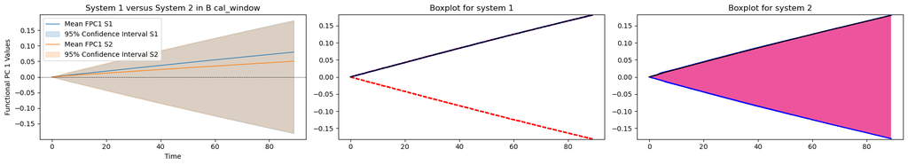

```
--------------------------------------------------- PCA Scores -------------------------------------------------------------------------------------------
```

[interactive chart not shown]

```python
pc_scores_s1_B_cal_window, pc_scores_s2_B_cal_window,fpca_s1_B_cal_window,fpca_s2_B_cal_window = fpca_two_inputs(B1_cal_window_combine_balanced.iloc[:,:-6], B2_cal_window_combine_balanced.iloc[:,:-6], color_fpc1_s1='tab:blue', color_fpc2_s1='tab:cyan', color_fpc1_s2='tab:orange', color_fpc2_s2='gold')
print("--------------------------------------------------- Bootstrap -------------------------------------------------------------------------------------------")
bc1,bc2 = bootstrap(B1_cal_window_combine_balanced, B2_cal_window_combine_balanced,"B","cal_window",features="FluidTempBin")
print("--------------------------------------------------- PCA Scores -------------------------------------------------------------------------------------------")
create_pc_scores_plots(pc_scores_s1_B_cal_window, pc_scores_s2_B_cal_window, B1_cal_window_combine_balanced, B2_cal_window_combine_balanced,features="FluidTempBin")
```

### System 1 versus System 2: Sensor B - Sample Window

```
S1 Explain variance PC1 (%):  99.8698403436696
S1 Explain variance PC2 (%):  0.03162176311685311
S2 Explain variance PC1 (%):  99.90746031021796
S2 Explain variance PC2 (%):  0.04126477921926537
The time series contributing most to PC1 is at index 203 with TestID 12191206.0
The time series contributing most to PC2 is at index 112 with TestID 12410993.0
The time series contributing most to PC1 is at index 5 with TestID 3518443.0
The time series contributing most to PC2 is at index 92 with TestID 3564548.0
```

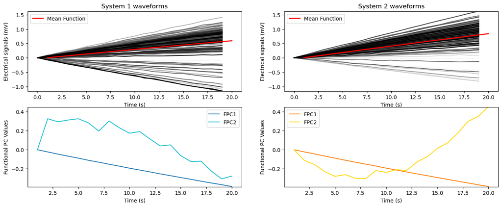

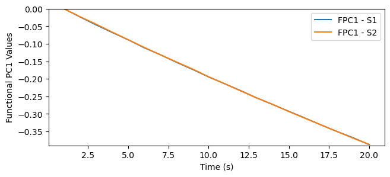

```
--------------------------------------------------- Bootstrap -------------------------------------------------------------------------------------------
Confidence Interval of 1st component
The number of sampling is 72
The boxplot of 1st Component
```

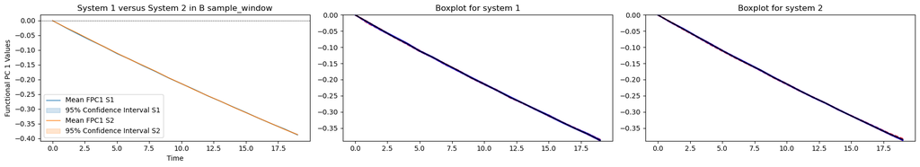

```
--------------------------------------------------- PCA Scores -------------------------------------------------------------------------------------------
```

[interactive chart not shown]

```python
pc_scores_s1_B_sample_window, pc_scores_s2_B_sample_window,fpca_s1_B_sample_window,fpca_s2_B_sample_window = fpca_two_inputs(B1_sample_window_combine_balanced.iloc[:,:-6], B2_sample_window_combine_balanced.iloc[:,:-6], color_fpc1_s1='tab:blue', color_fpc2_s1='tab:cyan', color_fpc1_s2='tab:orange', color_fpc2_s2='gold')
print("--------------------------------------------------- Bootstrap -------------------------------------------------------------------------------------------")
bs1,bs2 = bootstrap(B1_sample_window_combine_balanced, B2_sample_window_combine_balanced, "B","sample_window",features="FluidTempBin")
print("--------------------------------------------------- PCA Scores -------------------------------------------------------------------------------------------")
create_pc_scores_plots(pc_scores_s1_B_sample_window, pc_scores_s2_B_sample_window, B1_sample_window_combine_balanced, B2_sample_window_combine_balanced,features="FluidTempBin")
```

## 4.2 Linear Regression for slope

### R-square and visualization

```python
df_list = []
def append_to_dataframe(window_name, slope1, slope2,se1,se2,n,p):
    """
    Append regression analysis results to a global dataframe list.

    """
    global df_list
    df_list.append({'Window': window_name, 'Slope 1': slope1, 'Slope 2': slope2,'Se 1': se1, 'Se 2': se2, "N": n,"p_value":p})
```

```
                            OLS Regression Results
==============================================================================
Dep. Variable:                      y   R-squared:                       1.000
Model:                            OLS   Adj. R-squared:                  1.000
Method:                 Least Squares   F-statistic:                 6.015e+05
Date:                Sat, 22 Jun 2024   Prob (F-statistic):           2.09e-81
Time:                        08:06:35   Log-Likelihood:                 236.86
No. Observations:                  40   AIC:                            -469.7
Df Residuals:                      38   BIC:                            -466.3
Df Model:                           1
Covariance Type:            nonrobust
==============================================================================
                 coef    std err          t      P>|t|      [0.025      0.975]
------------------------------------------------------------------------------
const         -0.0061      0.000    -28.332      0.000      -0.007      -0.006
x1             0.0071   9.12e-06    775.552      0.000       0.007       0.007
==============================================================================
Omnibus:                        6.110   Durbin-Watson:                   0.465
Prob(Omnibus):                  0.047   Jarque-Bera (JB):                5.299
Skew:                          -0.886   Prob(JB):                       0.0707
Kurtosis:                       3.193   Cond. No.                         48.0
==============================================================================

Notes:
[1] Standard Errors assume that the covariance matrix of the errors is correctly specified.
                            OLS Regression Results
==============================================================================
Dep. Variable:                      y   R-squared:                       1.000
Model:                            OLS   Adj. R-squared:                  1.000
Method:                 Least Squares   F-statistic:                 5.792e+05
Date:                Sat, 22 Jun 2024   Prob (F-statistic):           4.27e-81
Time:                        08:06:35   Log-Likelihood:                 236.19
No. Observations:                  40   AIC:                            -468.4
Df Residuals:                      38   BIC:                            -465.0
Df Model:                           1
Covariance Type:            nonrobust
==============================================================================
                 coef    std err          t      P>|t|      [0.025      0.975]
------------------------------------------------------------------------------
const          0.0056      0.000     25.863      0.000       0.005       0.006
x1            -0.0071   9.27e-06   -761.059      0.000      -0.007      -0.007
==============================================================================
Omnibus:                        2.914   Durbin-Watson:                   0.186
Prob(Omnibus):                  0.233   Jarque-Bera (JB):                2.397
Skew:                           0.476   Prob(JB):                        0.302
Kurtosis:                       2.271   Cond. No.                         48.0
==============================================================================

Notes:
[1] Standard Errors assume that the covariance matrix of the errors is correctly specified.
```

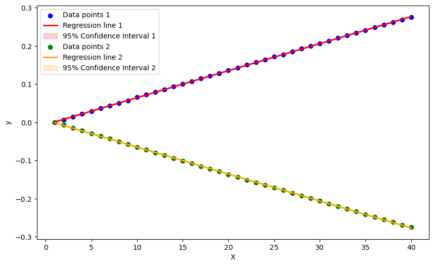

```
                            OLS Regression Results
==============================================================================
Dep. Variable:                      y   R-squared:                       1.000
Model:                            OLS   Adj. R-squared:                  1.000
Method:                 Least Squares   F-statistic:                 1.665e+05
Date:                Sat, 22 Jun 2024   Prob (F-statistic):           6.74e-46
Time:                        08:06:35   Log-Likelihood:                 131.48
No. Observations:                  25   AIC:                            -259.0
Df Residuals:                      23   BIC:                            -256.5
Df Model:                           1
Covariance Type:            nonrobust
==============================================================================
                 coef    std err          t      P>|t|      [0.025      0.975]
------------------------------------------------------------------------------
const         -0.0165      0.001    -30.544      0.000      -0.018      -0.015
x1             0.0148   3.64e-05    408.083      0.000       0.015       0.015
==============================================================================
Omnibus:                        1.899   Durbin-Watson:                   0.858
Prob(Omnibus):                  0.387   Jarque-Bera (JB):                1.098
Skew:                           0.121   Prob(JB):                        0.577
Kurtosis:                       2.002   Cond. No.                         30.8
==============================================================================

Notes:
[1] Standard Errors assume that the covariance matrix of the errors is correctly specified.
                            OLS Regression Results
==============================================================================
Dep. Variable:                      y   R-squared:                       1.000
Model:                            OLS   Adj. R-squared:                  1.000
Method:                 Least Squares   F-statistic:                 6.649e+04
Date:                Sat, 22 Jun 2024   Prob (F-statistic):           2.59e-41
Time:                        08:06:35   Log-Likelihood:                 120.68
No. Observations:                  25   AIC:                            -237.4
Df Residuals:                      23   BIC:                            -234.9
Df Model:                           1
Covariance Type:            nonrobust
==============================================================================
                 coef    std err          t      P>|t|      [0.025      0.975]
------------------------------------------------------------------------------
const         -0.0101      0.001    -12.082      0.000      -0.012      -0.008
x1             0.0144    5.6e-05    257.864      0.000       0.014       0.015
==============================================================================
Omnibus:                        2.611   Durbin-Watson:                   0.161
Prob(Omnibus):                  0.271   Jarque-Bera (JB):                2.207
Skew:                          -0.631   Prob(JB):                        0.332
Kurtosis:                       2.274   Cond. No.                         30.8
==============================================================================

Notes:
[1] Standard Errors assume that the covariance matrix of the errors is correctly specified.
```

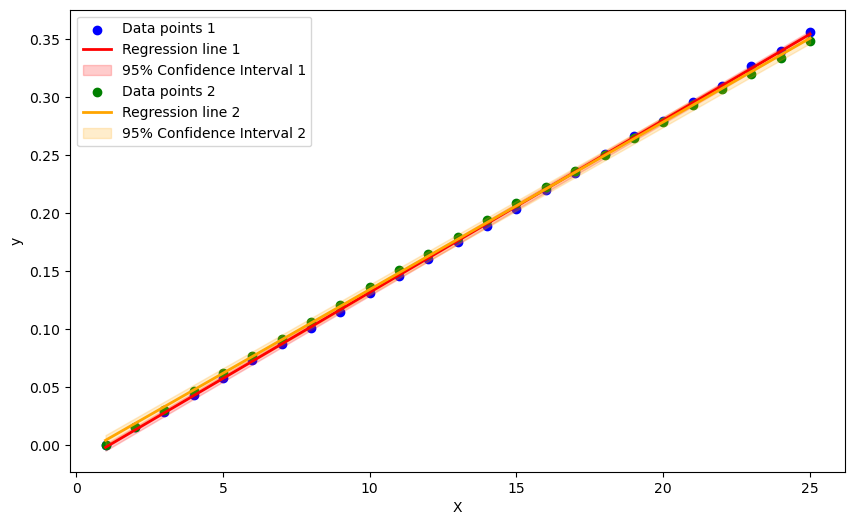

```
                            OLS Regression Results
==============================================================================
Dep. Variable:                      y   R-squared:                       1.000
Model:                            OLS   Adj. R-squared:                  1.000
Method:                 Least Squares   F-statistic:                 3.796e+05
Date:                Sat, 22 Jun 2024   Prob (F-statistic):          9.76e-162
Time:                        08:06:35   Log-Likelihood:                 513.47
No. Observations:                  90   AIC:                            -1023.
Df Residuals:                      88   BIC:                            -1018.
Df Model:                           1
Covariance Type:            nonrobust
==============================================================================
                 coef    std err          t      P>|t|      [0.025      0.975]
------------------------------------------------------------------------------
const         -0.0005      0.000     -2.784      0.007      -0.001      -0.000
x1             0.0020    3.3e-06    616.140      0.000       0.002       0.002
==============================================================================
Omnibus:                       10.659   Durbin-Watson:                   0.048
Prob(Omnibus):                  0.005   Jarque-Bera (JB):                7.235
Skew:                          -0.556   Prob(JB):                       0.0268
Kurtosis:                       2.167   Cond. No.                         106.
==============================================================================

Notes:
[1] Standard Errors assume that the covariance matrix of the errors is correctly specified.
                            OLS Regression Results
==============================================================================
Dep. Variable:                      y   R-squared:                       0.999
Model:                            OLS   Adj. R-squared:                  0.999
Method:                 Least Squares   F-statistic:                 1.404e+05
Date:                Sat, 22 Jun 2024   Prob (F-statistic):          9.85e-143
Time:                        08:06:35   Log-Likelihood:                 470.02
No. Observations:                  90   AIC:                            -936.0
Df Residuals:                      88   BIC:                            -931.0
Df Model:                           1
Covariance Type:            nonrobust
==============================================================================
                 coef    std err          t      P>|t|      [0.025      0.975]
------------------------------------------------------------------------------
const          0.0013      0.000      4.569      0.000       0.001       0.002
x1             0.0020   5.36e-06    374.661      0.000       0.002       0.002
==============================================================================
Omnibus:                        9.233   Durbin-Watson:                   0.015
Prob(Omnibus):                  0.010   Jarque-Bera (JB):                9.418
Skew:                          -0.746   Prob(JB):                      0.00901
Kurtosis:                       2.467   Cond. No.                         106.
==============================================================================

Notes:
[1] Standard Errors assume that the covariance matrix of the errors is correctly specified.
```

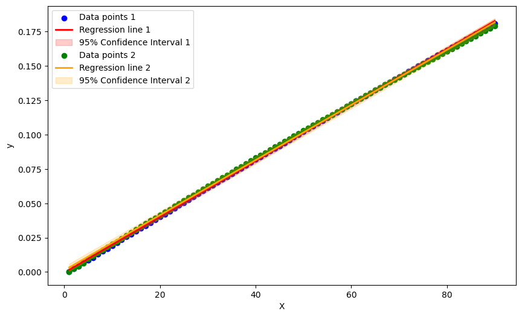

```
                            OLS Regression Results
==============================================================================
Dep. Variable:                      y   R-squared:                       0.999
Model:                            OLS   Adj. R-squared:                  0.999
Method:                 Least Squares   F-statistic:                 2.227e+04
Date:                Sat, 22 Jun 2024   Prob (F-statistic):           2.71e-29
Time:                        08:06:35   Log-Likelihood:                 85.722
No. Observations:                  20   AIC:                            -167.4
Df Residuals:                      18   BIC:                            -165.5
Df Model:                           1
Covariance Type:            nonrobust
==============================================================================
                 coef    std err          t      P>|t|      [0.025      0.975]
------------------------------------------------------------------------------
const          0.0130      0.002      7.972      0.000       0.010       0.016
x1            -0.0203      0.000   -149.231      0.000      -0.021      -0.020
==============================================================================
Omnibus:                        2.232   Durbin-Watson:                   0.192
Prob(Omnibus):                  0.328   Jarque-Bera (JB):                1.856
Skew:                           0.660   Prob(JB):                        0.395
Kurtosis:                       2.305   Cond. No.                         25.0
==============================================================================

Notes:
[1] Standard Errors assume that the covariance matrix of the errors is correctly specified.
                            OLS Regression Results
==============================================================================
Dep. Variable:                      y   R-squared:                       0.999
Model:                            OLS   Adj. R-squared:                  0.999
Method:                 Least Squares   F-statistic:                 2.212e+04
Date:                Sat, 22 Jun 2024   Prob (F-statistic):           2.89e-29
Time:                        08:06:35   Log-Likelihood:                 85.586
No. Observations:                  20   AIC:                            -167.2
Df Residuals:                      18   BIC:                            -165.2
Df Model:                           1
Covariance Type:            nonrobust
==============================================================================
                 coef    std err          t      P>|t|      [0.025      0.975]
------------------------------------------------------------------------------
const          0.0140      0.002      8.518      0.000       0.011       0.017
x1            -0.0204      0.000   -148.714      0.000      -0.021      -0.020
==============================================================================
Omnibus:                        2.467   Durbin-Watson:                   0.164
Prob(Omnibus):                  0.291   Jarque-Bera (JB):                1.874
Skew:                           0.600   Prob(JB):                        0.392
Kurtosis:                       2.101   Cond. No.                         25.0
==============================================================================

Notes:
[1] Standard Errors assume that the covariance matrix of the errors is correctly specified.
```

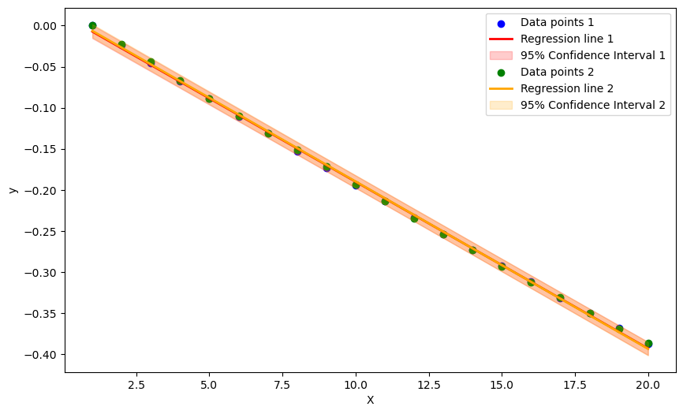

```python
append_to_dataframe('A_cal_window', *visualize_regression(fpca_s1_A_cal_window, fpca_s2_A_cal_window))
append_to_dataframe('A_sample_window', *visualize_regression(fpca_s1_A_sample_window, fpca_s2_A_sample_window))
append_to_dataframe('B_cal_window', *visualize_regression(fpca_s1_B_cal_window, fpca_s2_B_cal_window))
append_to_dataframe('B_sample_window', *visualize_regression(fpca_s1_B_sample_window, fpca_s2_B_sample_window))
```

### Slopes Results Comparison for one sample

```python
df = pd.DataFrame(df_list)
df.set_index("Window",inplace = True)
df[["Slope 1","Slope 2","p_value"]]
```

| Window | Slope 1 | Slope 2 | p_value |
| --- | --- | --- | --- |
| A_cal_window | 0.007072 | -0.007056 | 0.00 |
| A_sample_window | 0.014846 | 0.014447 | 0.00 |
| B_cal_window | 0.002036 | 0.002007 | 0.00 |
| B_sample_window | -0.020308 | -0.020375 | 0.73 |

# 5. Functional Regression

## 5.1. Regression coefficients

These are the coefficients from the output of the model.

- Note: In the visualizations, due to the different magnitude, we need to choose the time stamps before we visualize.

### Sensor A

#### Cal window

```python
print("System 1:")
A1_cal_window_funct_reg = Function_regression(A1_cal_window_combine_balanced,40,['Fluid_Temperature_Filled'])
print("----------------------------------------------------------------------------")
print("\n","System 2:")
A2_cal_window_funct_reg = Function_regression(A2_cal_window_combine_balanced,40,['Fluid_Temperature_Filled'])
```

```
System 1:
Model Summary:

Intercept: FDataBasis(
    _basis=FourierBasis(domain_range=((0.0, 39.0),), n_basis=41, period=39.0),
    coefficients=[[ 2.41023433e+00 -1.08219549e+00 -1.68023413e-01 -7.96298041e-01
      -9.56236134e-02 -3.09549036e-01 -4.78261523e-02 -6.65904915e-02
       7.71858107e-02 -1.46190019e-01  6.31016388e-02 -1.33551898e-01
       6.22052554e-02 -1.69748613e-01  1.12793918e-01 -1.58924811e-01
      -9.84046011e-02  7.71282155e-05  1.81279593e-02 -1.96544496e-01
       3.63989195e-03 -2.05879778e-01 -1.72159549e-01 -4.54719294e-01
      -7.81169149e-02 -1.44911057e-01 -2.29283723e-01 -3.36533478e-02
       7.05672869e-02 -2.91190701e-01  1.25409413e-01 -4.39002722e-01
      -1.42965486e-01 -5.27608587e-01 -2.49262028e-01 -6.50862552e-01
      -1.00996906e-01 -1.08212268e+14  7.05634914e+11 -1.08212268e+14
      -7.05634914e+11]])

Coefficient of Fluid_Temperature_Filled: FDataBasis(
    _basis=FourierBasis(domain_range=((0.0, 39.0),), n_basis=41, period=39.0),
    coefficients=[[-5.26916888e-02  2.31325646e-02  4.25996787e-03  2.50829631e-02
       1.24019702e-03  7.86285731e-03  2.44801147e-03 -1.91174909e-03
      -2.10206199e-03  1.48855206e-03 -2.19053346e-03  1.26678364e-03
      -3.31539485e-03  3.47218181e-03 -5.52568746e-03  3.99668590e-03
       3.80376959e-03 -2.75467677e-03 -1.84627367e-04  4.37018514e-03
       7.66333100e-04  4.57287492e-03  7.99573217e-03  1.57368804e-02
       2.82459092e-03  3.31483637e-03  8.99007532e-03 -2.02803547e-03
      -2.93591800e-03  8.06924035e-03 -3.89232458e-03  1.20569407e-02
       7.16360252e-03  1.21203480e-02  9.96301338e-03  1.27750653e-02
       3.14520291e-03  2.33851492e+12 -1.52490822e+10  2.33851492e+12
       1.52490822e+10]])

----------------------------------------------------------------------------

 System 2:
Model Summary:

Intercept: FDataBasis(
    _basis=FourierBasis(domain_range=((0.0, 39.0),), n_basis=41, period=39.0),
    coefficients=[[ 4.38324784e+00 -1.81936965e+00 -2.91543416e-01 -1.20760120e+00
      -4.87652888e-01 -3.72893617e-01 -1.45084859e-01 -2.07609112e-01
```

[output cut: 8 more lines]

```
      -1.39442794e+12]])

Coefficient of Fluid_Temperature_Filled: FDataBasis(
    _basis=FourierBasis(domain_range=((0.0, 39.0),), n_basis=41, period=39.0),
    coefficients=[[-1.42403619e-01  5.64409694e-02  1.03124638e-02  4.45287853e-02
       1.89000657e-02  1.06565587e-02  7.18999201e-03  4.16201357e-03
      -2.23579706e-02  1.46937872e-02  1.20715966e-02  1.14709358e-02
       4.78964926e-03  1.93912589e-02 -1.00691183e-02  3.48356944e-03
      -7.75002357e-03  2.53363784e-02 -9.50559462e-03  6.59628583e-03
       1.01548569e-02 -1.93683894e-02  5.25696033e-03 -1.05813471e-02
      -3.55715630e-03  3.48256250e-02  1.14241690e-02 -7.71137178e-03
       2.64628126e-02  6.57493423e-03  1.02707135e-02  2.07870239e-02
      -1.31751660e-02  2.13887471e-02 -8.07359263e-03  4.52536515e-02
      -1.18122912e-02  7.05347394e+12 -4.59945768e+10  7.05347394e+12
       4.59945768e+10]])
```

#### Sample window

```python
print("System 1:")
A1_sample_window_funct_reg = Function_regression(A1_sample_window_combine_balanced,25,["Fluid_Temperature_Filled"])
print("----------------------------------------------------------------------------")
print("\n","System 2:")
A2_sample_window_funct_reg = Function_regression(A2_sample_window_combine_balanced,25,["Fluid_Temperature_Filled"])
```

```
System 1:
Model Summary:

Intercept: FDataBasis(
    _basis=FourierBasis(domain_range=((0.0, 24.0),), n_basis=25, period=24.0),
    coefficients=[[ 8.65173425e-02 -9.55641898e-02  6.60601214e-02  9.90613376e-02
      -8.35165714e-02  3.01302362e-02 -2.30183054e-02  6.02886260e-03
       8.23897355e-03 -2.74959461e-02  1.15684728e-01 -1.32326603e-01
      -8.27230285e-03  6.37794182e-02 -5.41264545e-02 -8.74334422e-02
      -1.26097510e-01 -1.73907203e-01  5.97353292e-02 -1.02669020e-01
      -1.91582509e-01 -2.66029336e-01  1.61687511e-02 -4.64385989e+13
      -8.70264088e-02]])

Coefficient of Fluid_Temperature_Filled: FDataBasis(
    _basis=FourierBasis(domain_range=((0.0, 24.0),), n_basis=25, period=24.0),
    coefficients=[[-1.07390384e-02  5.25117960e-03 -6.66625393e-04 -3.55867735e-03
       3.80101127e-03 -2.31550753e-03  4.17905229e-04 -3.87059666e-04
      -1.24266988e-03  6.77848228e-04 -8.85154951e-03  1.15507960e-02
      -1.17172628e-03 -2.05873607e-03  3.59219878e-03  6.63051005e-03
       4.72048603e-03  9.36243450e-03 -2.23656185e-03  7.27688196e-03
       9.57220012e-03  1.45732638e-02  7.67765497e-04  4.52672476e+12
       8.52409333e-03]])

----------------------------------------------------------------------------

 System 2:
Model Summary:

Intercept: FDataBasis(
    _basis=FourierBasis(domain_range=((0.0, 24.0),), n_basis=25, period=24.0),
    coefficients=[[ 2.79841527e+00 -1.07569333e+00 -3.48394919e-01  9.67522155e-01
      -1.89671194e+00  4.25984492e-01 -4.44687188e-01 -1.13941630e+00
      -2.63516843e-01  2.30430216e-01  4.43613391e-02 -2.10851923e-01
       1.09454738e+00 -2.66578572e-01  1.27721786e-01 -7.74462459e-01
       2.62987089e-01 -1.09026475e+00  3.49320152e-01 -1.89926615e+00
      -1.23829141e+00 -1.40204206e+00 -5.27543888e-01 -8.72766089e+14
      -1.30269689e+00]])

Coefficient of Fluid_Temperature_Filled: FDataBasis(
    _basis=FourierBasis(domain_range=((0.0, 24.0),), n_basis=25, period=24.0),
    coefficients=[[-1.04452487e-01  4.26832556e-02  1.09288424e-02 -4.72228093e-02
       8.48785938e-02 -1.47327882e-02  2.19031164e-02  5.11590233e-02
       1.49539345e-02 -7.64900138e-03  1.28812278e-02 -1.37075463e-02
      -4.28538304e-02  9.87269782e-03 -1.07369912e-02  2.36964142e-02
      -1.13351115e-02  3.92120278e-02 -1.56546401e-02  7.50449200e-02
       4.92354368e-02  5.12180842e-02  1.85832043e-02  2.90800429e+13
       3.96475213e-02]])
```

### Sensor B

#### Cal window

```python
print("System 1:")
B1_cal_window_funct_reg = Function_regression(B1_cal_window_combine_balanced,90,["Fluid_Temperature_Filled"])
print("----------------------------------------------------------------------------")
print("\n","System 2:")
B2_cal_window_funct_reg = Function_regression(B2_cal_window_combine_balanced,90,["Fluid_Temperature_Filled"])
```

```
System 1:
Model Summary:

Intercept: FDataBasis(
    _basis=FourierBasis(domain_range=((0.0, 89.0),), n_basis=91, period=89.0),
    coefficients=[[ 1.35840633e+01 -6.18928012e+00 -9.79828601e-01 -1.55453409e+00
      -5.32923209e-02 -1.21528322e+00  4.49138971e-01 -1.41549103e+00
      -3.31102674e-01 -7.23035575e-01 -5.50676816e-01 -8.87708343e-02
       1.07041982e+00 -8.30226365e-01  9.34051641e-01 -5.47670208e-01
       2.62101215e-01 -2.30583680e-01  9.51493618e-01 -5.24489536e-01
       7.30465901e-01 -2.24155792e-01  1.04098020e+00 -2.73294499e+00
       1.27669730e-01 -9.59381942e-01 -3.77609644e-01 -1.60888144e+00
      -5.74201973e-01 -1.54652263e+00 -5.02028202e-01 -1.78723574e+00
       1.62420708e-01 -9.97429998e-01  1.65373012e-01 -9.05389092e-01
      -1.48338625e+00 -1.51233586e+00 -9.97482901e-01  5.05354837e-01
      -8.30066535e-01 -2.52193074e-01 -7.38790458e-01 -3.20692907e-01
      -1.27550952e+00 -2.73992325e-01  3.11750351e-02 -2.73157999e-01
      -8.39858764e-01  1.30314936e-01 -1.01484511e+00  1.19002298e+00
       5.70314859e-02  6.58585790e-01 -4.58358231e-02  9.61660774e-01
      -3.74506991e-01  1.62256439e+00  2.19228544e-01 -2.00973675e-01
       2.70781853e-01 -1.24305514e+00  4.75534549e-01 -3.69829932e-01
       1.03244870e+00 -3.09587455e-01  6.84705345e-01 -4.44378835e-01
      -6.10211583e-04 -7.16686357e-01  5.88951135e-01 -3.08402764e-01
       1.18318113e-01  1.08577703e+00  4.91540663e-01  1.17185661e+00
      -5.17260136e-01 -7.29889902e-01 -3.30979444e-01 -1.61573562e+00
      -4.92036592e-01  3.88587821e-01  2.29682891e-01 -2.05465192e+00
       1.92519820e-01 -1.34846441e+00 -8.31682885e-01 -4.67460455e+14
      -5.47200881e+12 -4.67460455e+14  5.47200881e+12]])

Coefficient of Fluid_Temperature_Filled: FDataBasis(
    _basis=FourierBasis(domain_range=((0.0, 89.0),), n_basis=91, period=89.0),
    coefficients=[[-4.70371352e-02  4.02243020e-02 -5.57111536e-03 -1.73414870e-02
      -4.39789894e-03 -2.81846482e-02 -7.35799454e-04  8.91427014e-03
      -3.04251135e-03  1.30465066e-02  5.80371776e-03 -1.62314826e-02
      -1.12279450e-03 -1.67950737e-03 -1.36670099e-02 -9.64539409e-03
      -1.06220407e-02 -1.58169169e-02 -1.97967904e-02 -1.83676131e-02
       4.63626701e-03 -4.17330170e-02 -2.53617802e-02  6.72376123e-02
      -2.94435820e-03 -2.22345346e-02  1.92719276e-02  1.43584015e-02
       7.23722697e-03  2.52074973e-02  1.28741184e-03  4.19826161e-02
      -3.91449145e-02  1.10906518e-02 -2.27980739e-02 -5.88451777e-03
```

[output cut: 56 more lines]

```
      -2.72822773e-02  4.06548925e-02 -1.30630919e-02 -4.40028535e-03
      -5.04309349e-02 -5.07635268e-02 -2.71982844e-02  1.10536146e-02
       6.97205125e-04  1.14819640e-02  1.49159503e-03 -1.69451227e-02
      -1.37181261e-02 -4.76272232e-02 -5.11953919e-02 -1.28391761e-02
      -2.30741457e-02  1.74674536e-02  1.60180905e-02  1.44907799e-02
       7.13747456e-04 -2.82162650e-02  1.50133209e-02 -5.21267734e-02
       3.66957989e-02 -8.13456209e-02  1.00758130e-02 -1.44664369e-02
       3.32906339e-02  2.47159664e-02  1.10194636e-02  1.85492966e-02
      -1.00588249e-02 -2.57378501e-03  2.54963526e-03  3.33354288e-02
      -5.51087390e-02 -5.26578852e-03  3.24913195e-04 -9.27674795e-03
      -2.57095975e-02  7.59515895e-02 -1.33407141e-02 -4.67825036e-02
      -7.64239950e-03 -5.66195727e-02 -6.04472723e-02 -6.55594157e-03
       2.30595543e-02 -6.27158112e-03 -1.07919839e-01 -9.25486321e-03
      -4.44262446e-02 -6.72801714e-02 -3.95560372e-02 -8.31562588e+12
      -9.73412351e+10 -8.31562588e+12  9.73412351e+10]])
```

#### Sample window

```python
print("System 1:")
B1_sample_window_funct_reg = Function_regression(B1_sample_window_combine_balanced,20,["Fluid_Temperature_Filled"])
print("----------------------------------------------------------------------------")
print("\n","System 2:")
B2_sample_window_funct_reg = Function_regression(B2_sample_window_combine_balanced,20,["Fluid_Temperature_Filled"])
```

```
System 1:
Model Summary:

Intercept: FDataBasis(
    _basis=FourierBasis(domain_range=((0.0, 19.0),), n_basis=21, period=19.0),
    coefficients=[[ 8.19868128e-01 -8.51963141e-01 -8.90369020e-02 -1.19430794e+00
      -1.36787195e-01 -5.35421424e-01  6.14395332e-01  6.98257199e-01
       2.90620675e-01 -6.47060885e-01  3.70471080e-01 -2.86255586e-01
       4.91456389e-01 -4.28719464e-01  4.15698478e-01 -8.60176055e-01
       4.42395227e-01 -3.40244324e+14 -8.27845071e+12 -3.40244324e+14
       8.27845071e+12]])

Coefficient of Fluid_Temperature_Filled: FDataBasis(
    _basis=FourierBasis(domain_range=((0.0, 19.0),), n_basis=21, period=19.0),
    coefficients=[[ 3.31441381e-02  1.42655172e-02  1.40768646e-02  3.88958108e-02
       1.89753598e-02  1.45542834e-02 -1.17814266e-02 -3.61048837e-02
       1.54178549e-03  1.93376548e-02 -1.77448531e-03  3.36667326e-03
      -6.01890914e-03  6.95452808e-03 -2.76293928e-03  1.79442455e-02
      -3.65159640e-03 -2.09190320e+12 -5.08978881e+10 -2.09190320e+12
       5.08978881e+10]])

----------------------------------------------------------------------------

 System 2:
Model Summary:

Intercept: FDataBasis(
    _basis=FourierBasis(domain_range=((0.0, 19.0),), n_basis=21, period=19.0),
    coefficients=[[ 1.12293911e+00 -4.49671541e-01  6.65196099e-02 -1.31252175e+00
      -9.67056213e-01 -6.74436490e-01  7.30782226e-01 -1.06548216e-02
       5.17535249e-01  1.50347765e-01 -1.60971250e-02 -1.83958127e+00
      -9.34415345e-01 -2.36950064e-01 -1.60054654e+00 -6.30634548e-01
      -1.74335998e+00 -3.73320923e+14 -9.08323415e+12 -3.73320923e+14
       9.08323415e+12]])

Coefficient of Fluid_Temperature_Filled: FDataBasis(
    _basis=FourierBasis(domain_range=((0.0, 19.0),), n_basis=21, period=19.0),
    coefficients=[[ 5.03685951e-02 -1.43347562e-02  1.31524655e-02  4.05519441e-02
       6.30014210e-02  1.95009762e-02 -1.17720797e-02 -9.25234260e-03
      -2.50686822e-03 -1.85921988e-02  2.26563755e-02  7.07759778e-02
       6.18124872e-02 -5.78135430e-03  9.41412011e-02  7.17034401e-04
       9.94808453e-02 -8.15488903e+12 -1.98415792e+11 -8.15488903e+12
       1.98415792e+11]])
```

## 5.2. Coefficients visualization

### Sensor A

#### Cal window

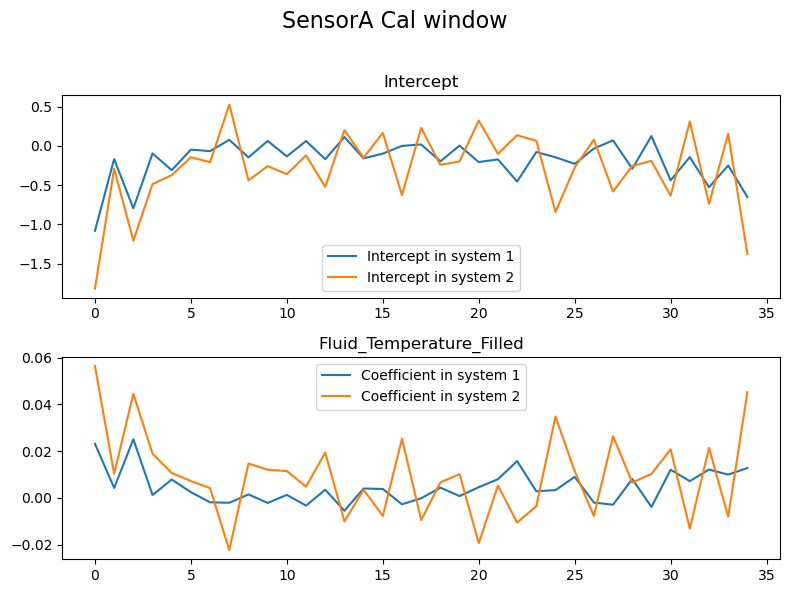

```python
coefficent_visualization(A1_cal_window_funct_reg,A2_cal_window_funct_reg,["Fluid_Temperature_Filled"],range(1,36),"SensorA Cal window")
```

#### Sample window

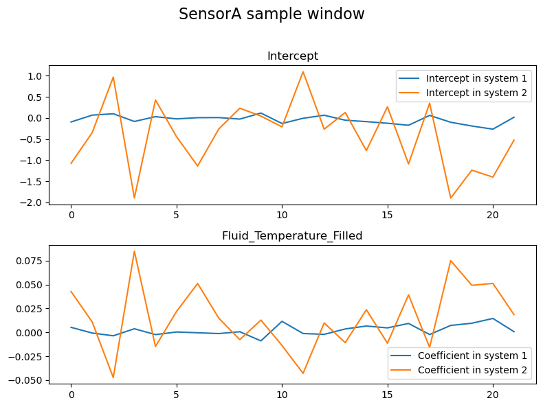

```python
coefficent_visualization(A1_sample_window_funct_reg,A2_sample_window_funct_reg,["Fluid_Temperature_Filled"],range(1,23),"SensorA sample window")
```

### Sensor B

#### Cal window

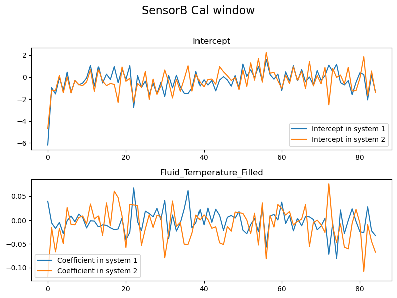

```python
coefficent_visualization(B1_cal_window_funct_reg,B2_cal_window_funct_reg,["Fluid_Temperature_Filled"],range(1,86),"SensorB Cal window")
```

#### Sample window

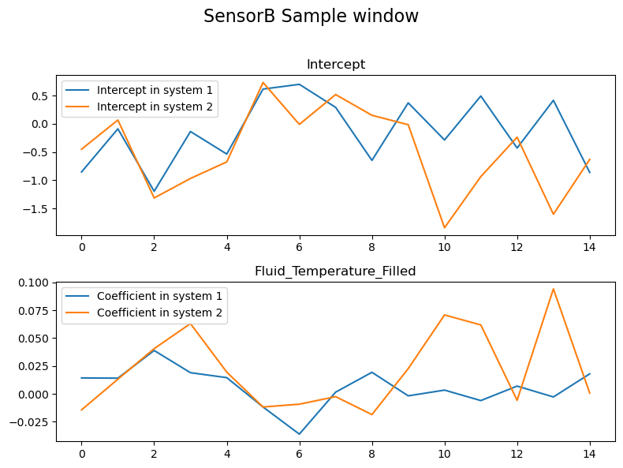

```python
coefficent_visualization(B1_sample_window_funct_reg, B2_sample_window_funct_reg, ["Fluid_Temperature_Filled"], range(1, 16), "SensorB Sample window")
```